# Exercises in variability downscaling

The purpose of this notebook is to explore techniques for downscaling annual totals to monthly totals, with variability in the fraction allocated to each month.

We will exercise our method on a synthetic data set constructed from Poisson-distributed random values. The lambda values will vary by month, so that the summer months have higher average values than the winter months; however, the Poisson distribution has variance equal to its mean, so there will be a lot of year to year variability in where the largest values are.

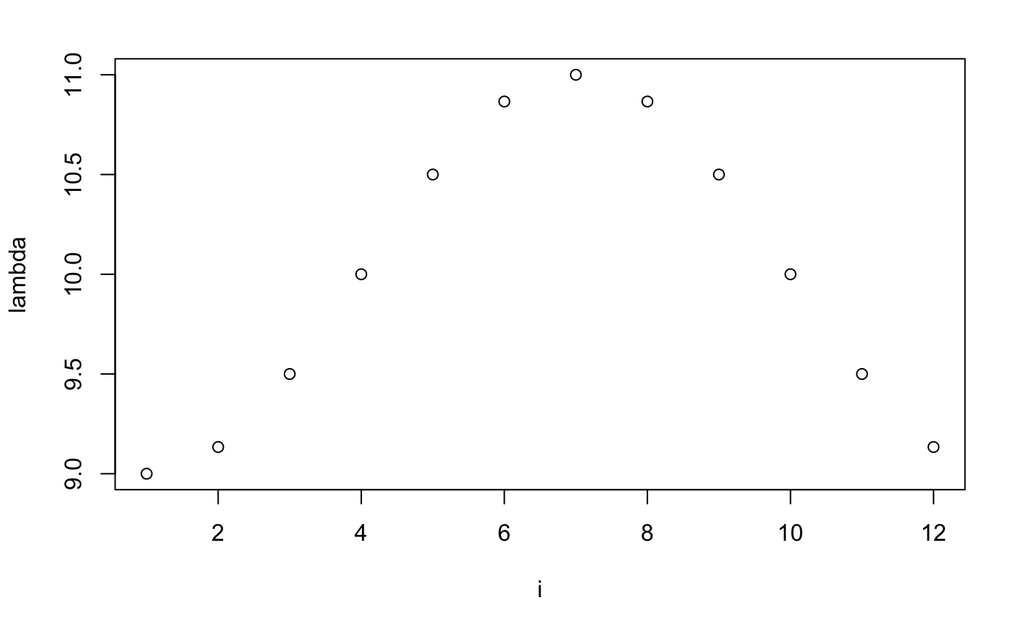

```r
i <- 1:12
lambda <- 10.0 - cos((i-1)/6 * pi)
plot(i, lambda)
```

Now, generate 100 years worth of data and put it into a matrix with years in rows. The raw counts are Poisson distributed (adding a small offset so that we don’t have zero values, which will cause problems later). The fractions are computed by dividing each row by its sum.

```r
set.seed(8675309)
counts <- matrix(0.1 + rpois(1200, lambda=lambda), ncol=12, byrow=TRUE)
x <- t(apply(counts, 1, function(x){x/sum(x)}))
```

Here are the first three data, expressed as counts

```r
plot(i, counts[2,], type='l', lty=2, xlab='Month', ylab='Counts')
lines(i, counts[1,], lty=1)
```

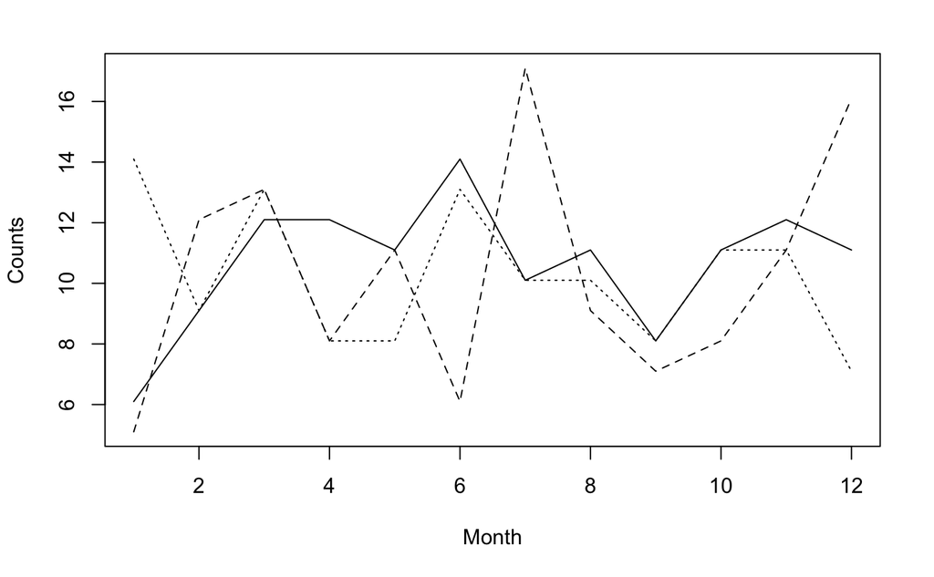

```r
lines(i, counts[3,], lty=3)
```

Check that the monthly average counts are what we expect

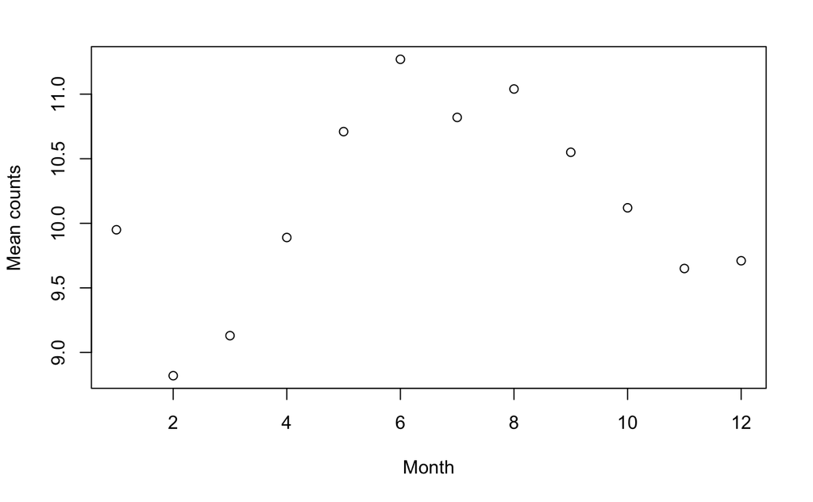

```r
mc <- apply(counts, 2, mean)
plot(i, mc, xlab='Month', ylab='Mean counts')
```

This appears to be a plausible approximation to what we put in, given the simulation noise.

And expressed as annual fraction

```r
plot(i, x[2,], type='l', lty=2, xlab='Month', ylab='Fraction')
lines(i, x[1,], lty=1)
```

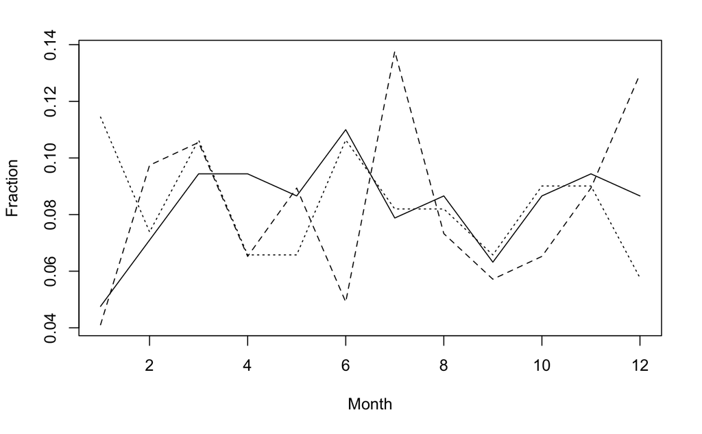

```r
lines(i, x[3,], lty=3)
```

Let’s check on the distributions of these variables. First define a utility function that runs the Shapiro-Wilk test of normality on each column of a matrix and then tells us which ones were significantly non-normal.

```r
swtest <- function(m) {tr <- apply(m, 2, shapiro.test); sapply(tr, function(x) {x$p.value > 0.05})}
```

We *don’t* expect the original counts data to be normally distributed, though some columns might be able to pass for normal. (A result of `FALSE` means the values were significantly non-normally distributed.)

```r
swtest(counts)
```

```
 [1]  TRUE  TRUE  TRUE FALSE FALSE  TRUE  TRUE FALSE  TRUE  TRUE  TRUE  TRUE
```

Roughly a quarter of the months were rejected by the test; the rest pass as normal, even though we know they’re not.

What about the x values?

```r
swtest(x)
```

```
 [1]  TRUE  TRUE  TRUE FALSE  TRUE  TRUE  TRUE FALSE  TRUE  TRUE  TRUE  TRUE
```

We can model the x values as coming from a [Dirichlet distribution](https://stats.stackexchange.com/a/244946). Fitting this model is challenging. The only thing I’ve been able to get to work is Monte Carlo sampling using the rstan package. (Unfortunately, this produces a *lot* of garbage output that can’t be suppressed.)

```r
library('rstan')
fit <- stan('monfrac2.stan', data=list(Nyear=100, monfrac_obs=x), iter=2000, verbose=FALSE,
            refresh=0, chains=1, seed=24601)
```

```
Gradient evaluation took 0.000457 seconds
1000 transitions using 10 leapfrog steps per transition would take 4.57 seconds.
Adjust your expectations accordingly!



 Elapsed Time: 6.32552 seconds (Warm-up)
               5.41019 seconds (Sampling)
               11.7357 seconds (Total)
```

```r
fitdata <- extract(fit)
xsim <- fitdata$monfrac
```

Plotting the Dirichlet distribution is not easy because it’s inherently multivariate, and you can’t change one of the values without changing at least one of the others (because they must sum to 1.) Instead, we can take the samples from the distribution and plot histograms of their marginals.

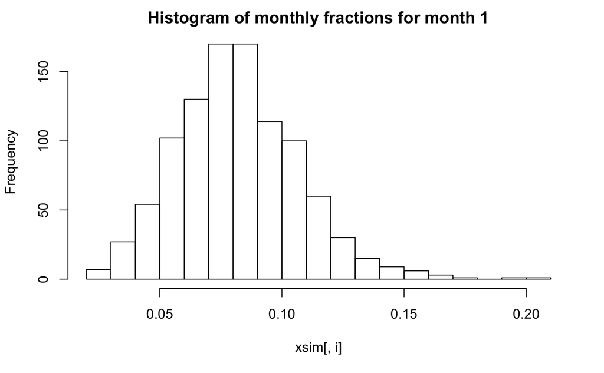

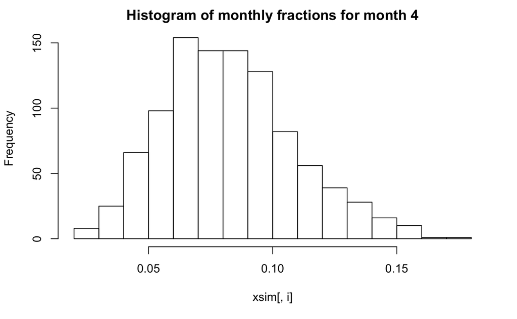

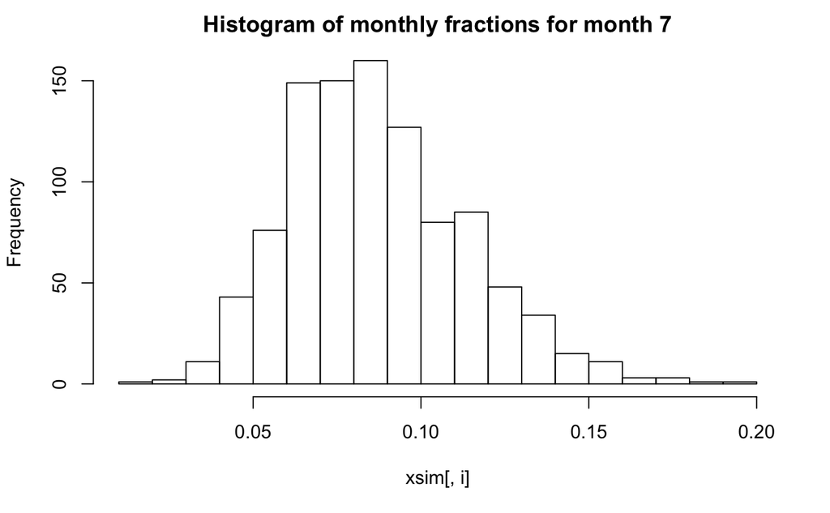

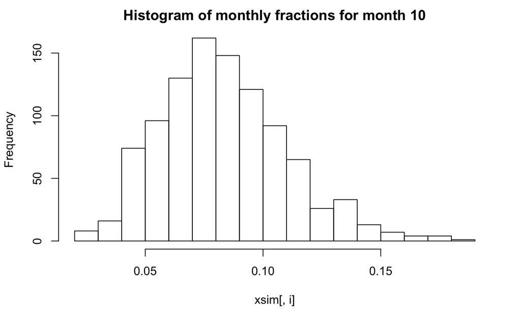

```r
for(i in c(1,4,7,10)) {
  hist(xsim[,i], breaks = 20, main=paste('Histogram of monthly fractions for month', i))
}
```

We can also plot a pair of months against one another.

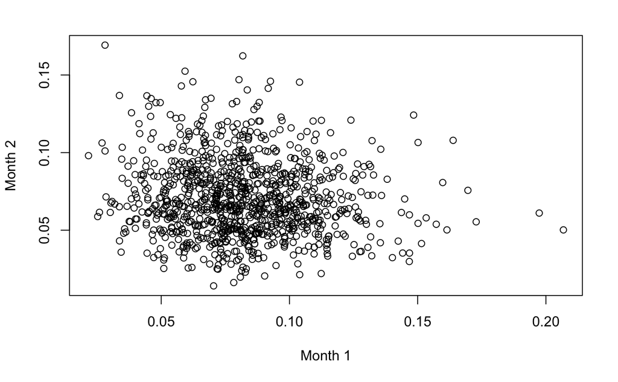

```r
plot(xsim[,1], xsim[,2], xlab='Month 1', ylab='Month 2')
```

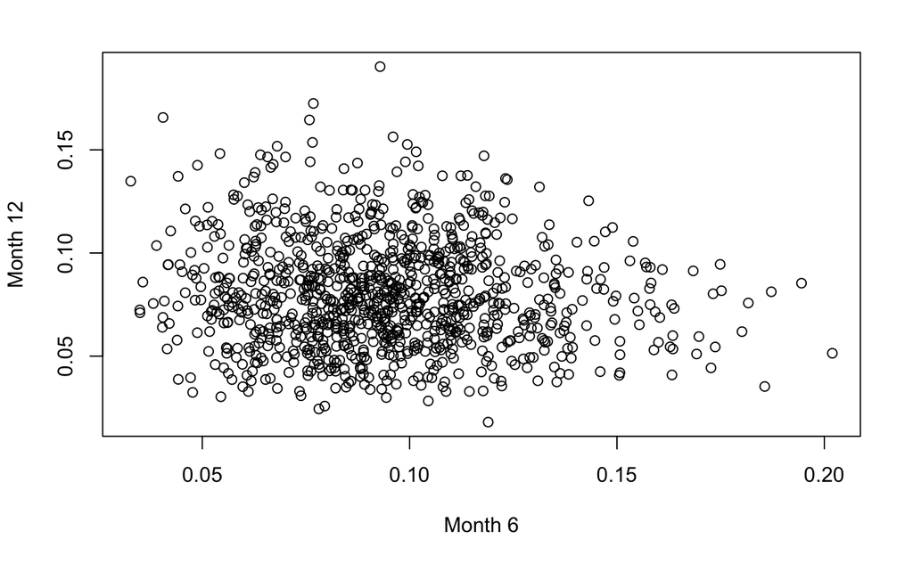

```r
plot(xsim[,6], xsim[,12], xlab='Month 6', ylab='Month 12')
```

These look plausibly related to the reference distributions above, but we should do some quantitative tests.

```r
suppressWarnings(sapply(1:12, function(i) {ks.test(x[,i], xsim[,i])$p.value}))
```

```
 [1] 0.8633792 0.6699359 0.9096696 0.5272487 0.1659060 0.8091049 0.7491706 0.6057167 0.8989582
[10] 0.9811673 0.3719278 0.7491706
```

The K-S test fails to reject any of the marginal monthly distributions, which suggests that they are probably good enough for our purposes here.

An alternate possibility, which doesn’t involve running a stan program every time, is to find the mean alpha values using stan, then draw from the corresponding Dirichlet distribution using `gtools::rdirichlet`.

```r
alpha0 <- apply(fitdata$alpha, 2, mean)
alpha0
```

```
 [1]  9.176702  8.051116  8.450600  9.137146  9.937235 10.474052  9.717743 10.284772  9.757065
[10]  9.260241  9.001906  8.967876
```

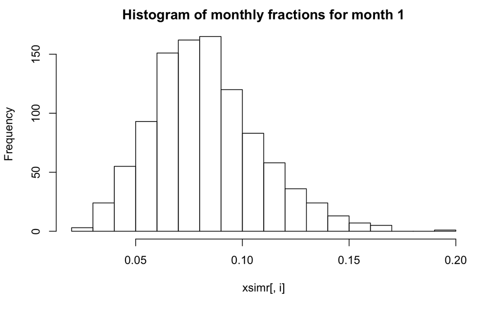

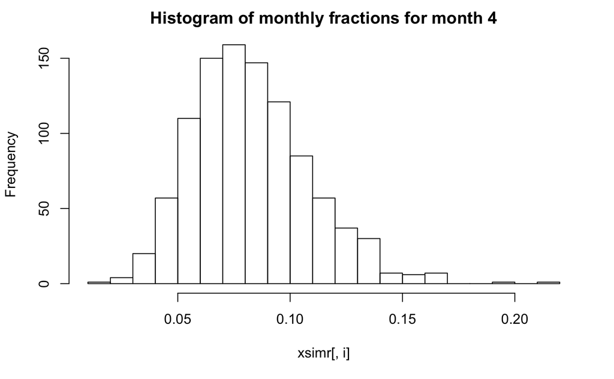

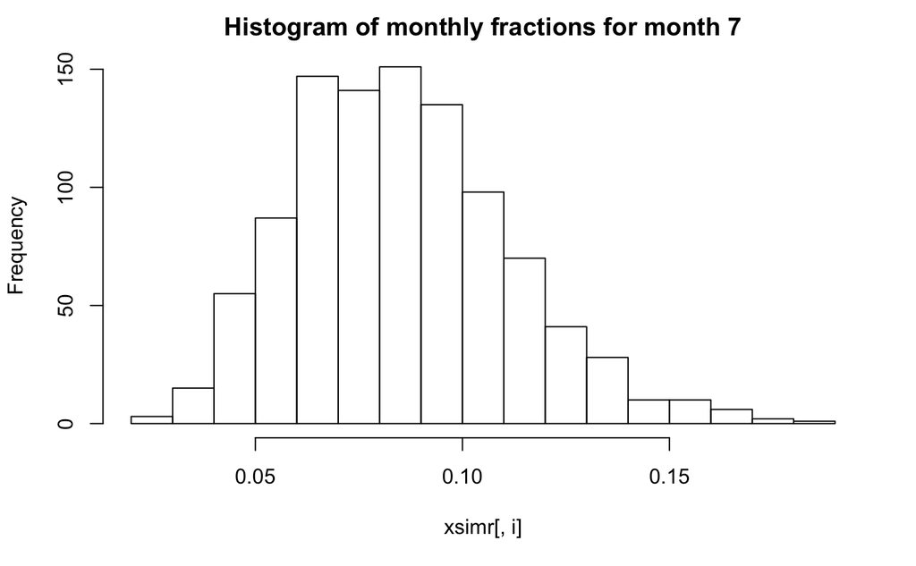

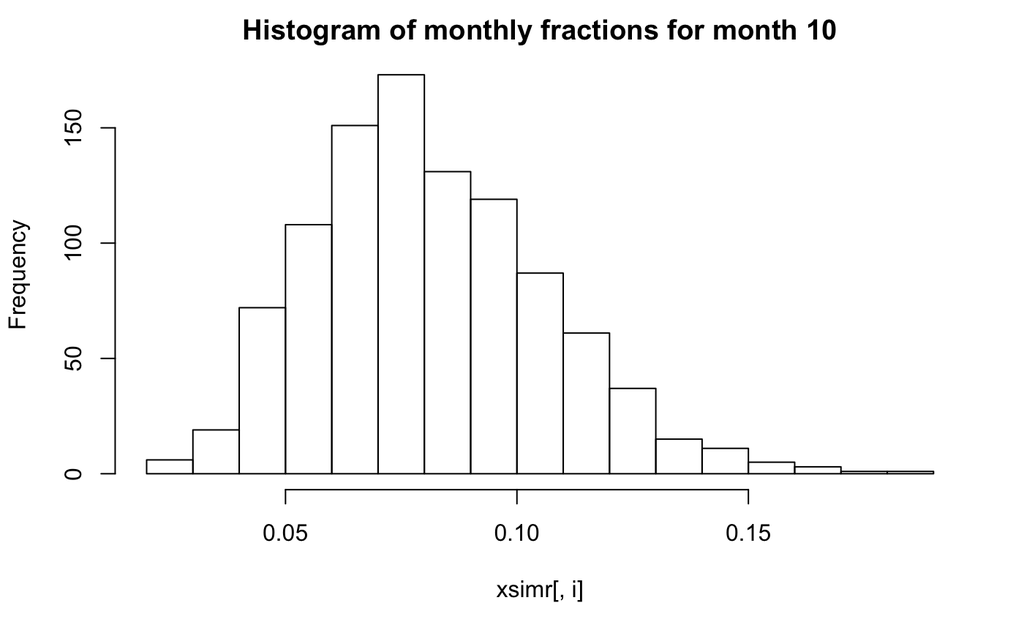

```r
xsimr <- gtools::rdirichlet(nrow(xsim), alpha0)
for(i in c(1,4,7,10)) {
  hist(xsimr[,i], breaks = 20, main=paste('Histogram of monthly fractions for month', i))
}
```

```r
suppressWarnings(sapply(1:12, function(i) {ks.test(x[,i], xsimr[,i])$p.value}))
```

```
 [1] 0.9292197 0.8989582 0.8232990 0.4389089 0.3232660 0.5120071 0.2897472 0.3006353 0.7645515
[10] 0.7335872 0.1589775 0.9380223
```

These also seem to be a good match to the input distribution. Can we even tell the difference between the full simulation (i.e., using Stan) and the ones using `rdirichlet`?

```r
suppressWarnings(sapply(1:12, function(i) {ks.test(xsim[,i], xsimr[,i])$p.value}))
```

```
 [1] 0.72255496 0.57265485 0.50035949 0.88793861 0.68523140 0.28771980 0.40047367 0.50035949
 [9] 0.40047367 0.09710452 0.40047367 0.82795686
```

These results suggest that doing the sampling in Stan, instead of in R, doesn’t produce an appreciably different distribution. This is good news indeed, as it means that although we need to do some Stan runs as part of our data preparation, we can just store the `alpha0` parameters for each grid cell as part of the processed model data. When we actually do our analysis runs, we can just feed those parameters into `rdirichlet`, which is both faster and produces less junk on the console.